# Wstęp do Uczenia Maszynowego 2020: projekt I [kamień milowy I]

Jakub Kosterna, Marcin Łukaszyk, Mikołaj Malec

16/03/2020

# 1. Wstęp i pierwszy ogląd

Poniżej znajduje sie raport z analizy zbioru danych dotyczących klientów banku. Dane zostały pobrane z [tej strony](https://www.mldata.io/dataset-details/german_credit_data/#customize_download).

Zanim zaczniemy właściwą robotę, wczytajmy potrzebne pakiety.

```r
# install.packages("dplyr") # if not installed
library(dplyr)
# install.packages("ggplot2") # if not installed
library(ggplot2)
# install.packages("DataExplorer") # if not installed
library(DataExplorer)
```

Otwórzmy także naszą ramkę danych i upewnijmy się, że została ona wczytana poprawnie.

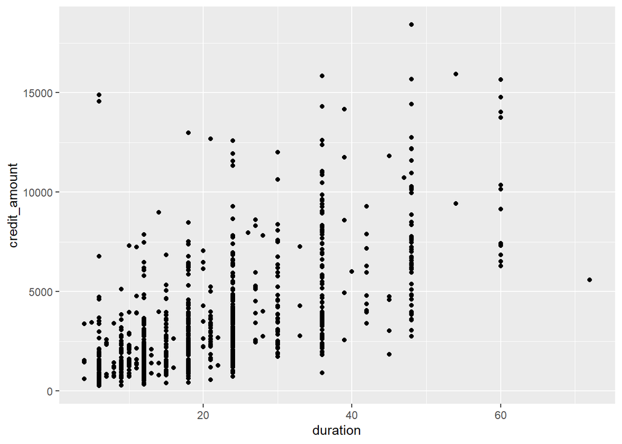

```r
data <- read.csv("german_credit_data_weka_dataset.csv")
ggplot(data = data,aes(x = duration,y = credit_amount)) +
  geom_point()
```

```r
set.seed(124)
knitr::kable(sample_n(data, 10))
```

| checking_account_status | duration | credit_history | purpose | credit_amount | savings | present_employment | installment_rate | personal | other_debtors | present_residence | property | age | other_installment_plans | housing | existing_credits | job | dependents | telephone | foreign_worker | customer_type |
| --- | --- | --- | --- | --- | --- | --- | --- | --- | --- | --- | --- | --- | --- | --- | --- | --- | --- | --- | --- | --- |
| A12 | 30 | A34 | A40 | 4249 | A61 | A71 | 4 | A94 | A101 | 2 | A123 | 28 | A143 | A152 | 2 | A174 | 1 | A191 | A201 | 2 |
| A11 | 18 | A32 | A42 | 1131 | A61 | A71 | 4 | A92 | A101 | 2 | A123 | 33 | A143 | A152 | 1 | A173 | 1 | A191 | A201 | 2 |
| A12 | 24 | A32 | A43 | 1967 | A61 | A75 | 4 | A92 | A101 | 4 | A123 | 20 | A143 | A152 | 1 | A173 | 1 | A192 | A201 | 1 |
| A11 | 12 | A32 | A42 | 1657 | A61 | A73 | 2 | A93 | A101 | 2 | A121 | 27 | A143 | A152 | 1 | A173 | 1 | A191 | A201 | 1 |
| A11 | 18 | A32 | A43 | 1882 | A61 | A73 | 4 | A92 | A101 | 4 | A123 | 25 | A141 | A151 | 2 | A173 | 1 | A191 | A201 | 2 |
| A14 | 9 | A32 | A49 | 1449 | A61 | A74 | 3 | A92 | A101 | 2 | A123 | 27 | A143 | A152 | 2 | A173 | 1 | A191 | A201 | 1 |
| A14 | 9 | A32 | A42 | 1313 | A61 | A75 | 1 | A93 | A101 | 4 | A123 | 20 | A143 | A152 | 1 | A173 | 1 | A191 | A201 | 1 |
| A12 | 42 | A34 | A49 | 5954 | A61 | A74 | 2 | A92 | A101 | 1 | A121 | 41 | A141 | A152 | 2 | A172 | 1 | A191 | A201 | 1 |
| A14 | 30 | A32 | A43 | 1867 | A65 | A75 | 4 | A93 | A101 | 4 | A123 | 58 | A143 | A152 | 1 | A173 | 1 | A192 | A201 | 1 |
| A12 | 12 | A32 | A40 | 1223 | A61 | A75 | 1 | A91 | A101 | 1 | A121 | 46 | A143 | A151 | 2 | A173 | 1 | A191 | A201 | 2 |

Dane w takiej postaci dużo nam nie mówią - na szczęście dziękim dostępnym szczegółom poszczególnych oznaczeń możemy lepiej zorientować się, o co w tym wszystkim biega.

# 2. Czyszczenie danych

W celu ludzkiego przedstawienia danych zmodyfikujemy je tak, żeby wszystko stało się jasne.

```r
# przeksztalcanie na dane numeryczne i z faktorami
levels(data[,1]) <- c("low", "fair", "high", "not_have") #DM low<0<fair<200<high
levels(data[,3]) <- c("all_paid", "all_paid_here", "paid_till_now", "delay", "critical")
levels(data[,4]) <- c("new_car", "used_car", "furniture/equipment", "radio/television", "domestic", "repairs", "education", "retraining", "business", "other") #note: 0 for vacation
levels(data[,6]) <- c("low","normal","high","very_high","not_have/unknown") #DM low<100<normal<500<high<1000<very_high
levels(data[,7]) <- c("unemployed", "less_than_year", "1-3_years", "4-6_yeras","7+_years")
levels(data[,9]) <- c("male_d/s", "female_d/s/m", "male_single", "male_m/w") #d = divorsed, s = seperated, m = married, w = widowed ,#note: 0 female single
levels(data[,10]) <- c("none", "co-applicant", "guarantor")
levels(data[,12]) <- c("real_estate", "building_savings", "car", "not_have/unknown")
levels(data[,14]) <- c("bank", "stores", "none")
levels(data[,15]) <- c("rent", "own", "for_free")
levels(data[,17]) <- c("unskilled_non_resident", "unskilled_resident", "skilled_eployee", "highly_qualified_employee*") # also management, self-employed, officer
levels(data[,19]) <- c("no", "yes")
levels(data[,20]) <- c("yes", "no")
data[,21] <- as.factor(as.character(data[,21]))
levels(data[,21]) <- c("Good", "Bad")
```

Jak teraz wygąląda nasze losowe 20 wierszy?

```r
knitr::kable(sample_n(data, 20))
```

| checking_account_status | duration | credit_history | purpose | credit_amount | savings | present_employment | installment_rate | personal | other_debtors | present_residence | property | age | other_installment_plans | housing | existing_credits | job | dependents | telephone | foreign_worker | customer_type |
| --- | --- | --- | --- | --- | --- | --- | --- | --- | --- | --- | --- | --- | --- | --- | --- | --- | --- | --- | --- | --- |
| low | 15 | paid_till_now | new_car | 3959 | low | 1-3_years | 3 | female_d/s/m | none | 2 | building_savings | 29 | none | own | 1 | skilled_eployee | 1 | yes | yes | Bad |
| fair | 15 | paid_till_now | new_car | 2631 | normal | 1-3_years | 2 | female_d/s/m | none | 4 | car | 28 | none | rent | 2 | skilled_eployee | 1 | yes | yes | Bad |
| low | 18 | critical | education | 1190 | low | unemployed | 2 | female_d/s/m | none | 4 | not_have/unknown | 55 | none | for_free | 3 | unskilled_non_resident | 2 | no | yes | Bad |
| fair | 18 | delay | radio/television | 4297 | low | 7+_years | 4 | male_d/s | none | 3 | not_have/unknown | 40 | none | own | 1 | highly_qualified_employee* | 1 | yes | yes | Bad |
| not_have | 24 | paid_till_now | domestic | 1311 | normal | 4-6_yeras | 4 | male_m/w | none | 3 | building_savings | 26 | none | own | 1 | skilled_eployee | 1 | yes | yes | Good |
| high | 15 | paid_till_now | retraining | 1905 | low | 7+_years | 4 | male_single | none | 4 | car | 40 | none | rent | 1 | highly_qualified_employee* | 1 | yes | yes | Good |
| fair | 10 | all_paid_here | domestic | 1048 | low | 1-3_years | 4 | male_single | none | 4 | real_estate | 23 | stores | own | 1 | unskilled_resident | 1 | no | yes | Good |
| fair | 15 | paid_till_now | education | 1308 | low | 7+_years | 4 | male_single | none | 4 | car | 38 | none | own | 2 | unskilled_resident | 1 | no | yes | Good |
| fair | 27 | critical | domestic | 2520 | high | 1-3_years | 4 | male_single | none | 2 | building_savings | 23 | none | own | 2 | unskilled_resident | 1 | no | yes | Bad |
| not_have | 24 | critical | radio/television | 1585 | low | 4-6_yeras | 4 | male_single | none | 3 | building_savings | 40 | none | own | 2 | skilled_eployee | 1 | no | yes | Good |
| low | 24 | critical | domestic | 1231 | very_high | 7+_years | 4 | female_d/s/m | none | 4 | building_savings | 57 | none | rent | 2 | highly_qualified_employee* | 1 | yes | yes | Good |
| fair | 6 | paid_till_now | education | 454 | low | less_than_year | 3 | male_m/w | none | 1 | building_savings | 22 | none | own | 1 | unskilled_resident | 1 | no | yes | Good |
| high | 24 | paid_till_now | radio/television | 2892 | low | 7+_years | 3 | male_d/s | none | 4 | not_have/unknown | 51 | none | for_free | 1 | skilled_eployee | 1 | no | yes | Good |
| low | 60 | delay | other | 6836 | low | 7+_years | 3 | male_single | none | 4 | not_have/unknown | 63 | none | own | 2 | skilled_eployee | 1 | yes | yes | Bad |
| low | 30 | paid_till_now | used_car | 3857 | low | 1-3_years | 4 | male_d/s | none | 4 | building_savings | 40 | none | own | 1 | highly_qualified_employee* | 1 | yes | yes | Good |
| fair | 24 | paid_till_now | new_car | 1355 | low | less_than_year | 3 | female_d/s/m | none | 4 | car | 25 | none | own | 1 | unskilled_resident | 1 | yes | yes | Bad |
| low | 48 | paid_till_now | new_car | 7763 | low | 7+_years | 4 | male_single | none | 4 | not_have/unknown | 42 | bank | for_free | 1 | highly_qualified_employee* | 1 | no | yes | Bad |
| not_have | 18 | critical | domestic | 629 | high | 7+_years | 4 | male_single | none | 3 | building_savings | 32 | bank | own | 2 | highly_qualified_employee* | 1 | yes | yes | Good |
| fair | 10 | paid_till_now | new_car | 7308 | low | unemployed | 2 | male_single | none | 4 | not_have/unknown | 70 | bank | for_free | 1 | highly_qualified_employee* | 1 | yes | yes | Good |
| fair | 39 | delay | retraining | 11760 | normal | 4-6_yeras | 2 | male_single | none | 3 | not_have/unknown | 32 | none | rent | 1 | skilled_eployee | 1 | yes | yes | Good |

Doskonale!

# 3. Eksploracja

## 3.1. Automatyczny ogląd

Poznaliśmy już bardzo wygodne narzędzie jakim jest *DataExplorer*. Wykorzystajmy je na początek naszej analizy.

```r
DataExplorer::create_report(data)
```

Co możemy wywnioskować po przyjrzeniu się bardzo przyjemnemu raportowi, który można znaleźć w pliku *report.html*?

1. Zbiór danych nie jest jakiś ogromny - ma zaledwie **1000 wierszy** i **21 kolumn**.
2. 2/3 kolumn reprezentuje wartości dyskretne - pozostałe - ciągłe.
3. Nie mamy do czynienia z **żadnymi brakami danych**.
4. Przeważają klienci w wieku lat 20-40, potem mniej-więcej im starsza grupa, tym mniej osobników.
5. Kredyt zwykle zostaje wzięty na parę tysięcy Euro.
6. Pożyczka jest brana zwykle na okres od kilku miesięcy do paru lat.
7. Większość osobników wzięła tylko pojedynczy kredyt, ale niektórzy także na 2, 3 lub 4.
8. Ogromna część klientów wywiązuje się ze spłacania pożyczki.
9. Najczęstsze podawane powody wzięcia kredytu to te na dom, samochód czy radio / telewizję.
10. Większość klientów nie może się pochwalić sporą ilością oszczędności i często również długim stażem zatrudnienia.
11. Spośród grupy 1000 osób które skorzystały z usługi w banku prawie 600 to nieżonaci mężczyźni.

## 3.2. Dodatkowe wnioski

Poszukajmy jeszcze ręcznie jakichś ciekawych własności i faktów, które wynikają z naszej ramki.

Dla przypomnienia

```r
colnames(data)
```

```
##  [1] "checking_account_status" "duration"
##  [3] "credit_history"          "purpose"
##  [5] "credit_amount"           "savings"
##  [7] "present_employment"      "installment_rate"
##  [9] "personal"                "other_debtors"
## [11] "present_residence"       "property"
## [13] "age"                     "other_installment_plans"
## [15] "housing"                 "existing_credits"
## [17] "job"                     "dependents"
## [19] "telephone"               "foreign_worker"
## [21] "customer_type"
```

### 3.2.1. Potrzeby męskie a żeńskie

Czy klienci okazali się stereotypowi i to facet prędzej sięgnie po pieniądze na telewizor zaś kobieta na gospodarstwo domowe?

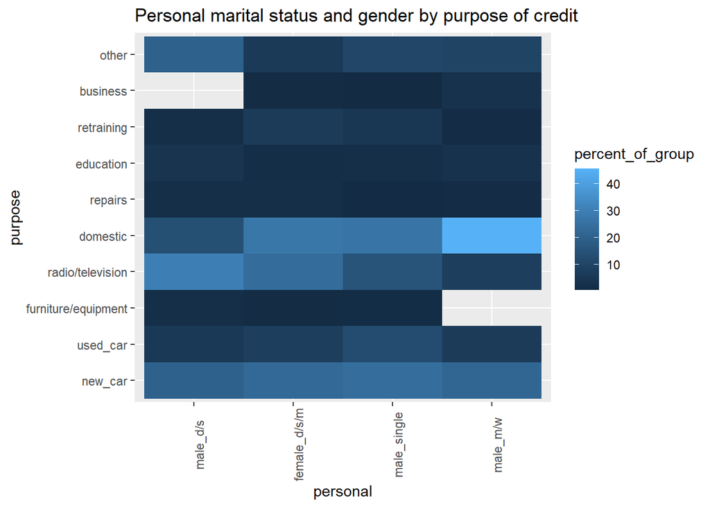

```r
n_of_personal <- data %>%
  group_by(personal) %>%
  count()

data_1 <- data %>%
  select("purpose", "personal") %>%
  group_by(personal, purpose) %>%
  count() %>%
  inner_join(n_of_personal, by = "personal") %>%
  mutate(percent_of_group = n.x / n.y * 100) %>%
  select(-c(n.x, n.y))

ggplot(data_1, aes(fill = percent_of_group, x = personal, y = purpose)) +
  geom_tile() +
  ggtitle("Personal marital status and gender by purpose of credit") +
  theme(axis.text.x = element_text(angle = 90))
```

Okazuje się, że stereotypy można wyrzucić do kosza - mężczyźni o wiele częściej biorą kredyt ze względu na potrzebę funduszy na gospodarstwo domowe i nie widać znaczącej przewagi w stosunku do kobiet jeśli idzie o chęć postawienia pieniędzy na auto.

Bez zaskoczeń o wiele częściej na dom stawiają mężczyźni po ślubie niż ci samotni czy rozwodnicy. Co ciekawe ci sami ani razu nie wzięli pożyczki na wyposażenie / meble [przynajmniej na te 1000 osobników], zaś rozwodnicy i separatyści… przeciwnie do pozostałych grup nie myślą tu wręcz wcale o dodatkowej mamonie na biznes.

### 3.2.2. Wiek a przewidywane spłacenie kredytu

Czy abstrahując od kilkunastu ważnych parametrów - to raczej stosunkowo młodzi ludzie biorą uznawani są za tych, którzy pożyczki nie spłacą?

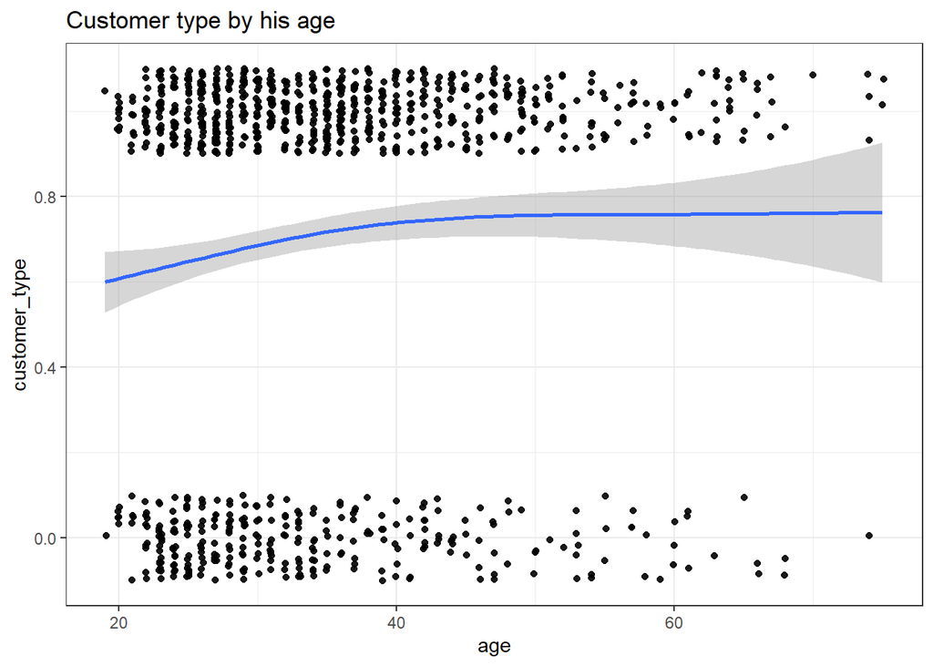

```r
data_2 <- data %>% select(customer_type, age)
data_2 <- data_2 %>% mutate(customer_type = ifelse(customer_type == "Good", 1, 0))

ggplot(data_2, aes(x = age, y = customer_type)) +
  geom_jitter(alpha = 0.9, width = 0.1, height = 0.1) +
  ggtitle("Customer type by his age") +
  geom_smooth() +
  theme_bw()
```

## 4. Zakończenie

To by było na tyle.